# Lecture 17: Numerical Optimization

author: date: 9 November transition: None font-family: Garamond

# Agenda

- Basics of optimization
- Gradient descent
- Newton’s method
- Curve-fitting
- R: `optim`

# Examples of Optimization Problems

- Minimize mean-squared error of regression (Gauss, c. 1800)
- Maximize likelihood of distribution (Fisher, c. 1918)

# Optimization Problems

Given an **objective function** $f: \mathcal{D} \mapsto R$, find $\DeclareMathOperator*{\argmax}{argmax} \DeclareMathOperator*{\argmin}{argmin} \theta^* = \argmin_{\theta}{f(\theta)}$

Basics: maximizing $f$ is minimizing $-f$: $\argmax_{\theta}{f(\theta)}= \argmin_{\theta}{-f(\theta)}$

If $h$ is strictly increasing (e.g., $\log$), then $\argmin_{\theta}{f(\theta)} = \argmin_{\theta}{h(f(\theta))}$

# Considerations

- Approximation: How close can we get to $\theta^*$, and/or $f(\theta^*)$?
- Time complexity: How many computer steps does that take?
- Varies with precision of approximation, niceness of $f$, size of $\mathcal{D}$, size of data, method…
- Most optimization algorithms use **successive approximation**, so distinguish number of iterations from cost of each iteration

# You remember calculus, right?

Suppose $x$ is one dimensional and $f$ is smooth. If $x^*$ is an **interior** minimum / maximum / extremum point ${\left. \frac{df}{dx} \right|}_{x=x^*} = 0$

If $x^*$ a minimum, ${\left. \frac{d^2f}{dx^2}\right|}_{x=x^*} > 0$

# You remember calculus, right?

This all carries over to multiple dimensions: At an **interior extremum**, $\nabla f(\theta^*) = 0$

At an **interior minimum**, $\nabla^2 f(\theta^*) \geq 0$

meaning for any vector $v$, $v^T \nabla^2 f(\theta^*) v \geq 0$ $\nabla^2 f =$ the **Hessian**, $\mathbf{H}$

$\theta^*$ might just be a **local** minimum

# Gradients and Changes to f

$f^{\prime}(x_0) = {\left. \frac{df}{dx}\right|}_{x=x_0} = \lim_{x\rightarrow x_0}{\frac{f(x)-f(x_0)}{x-x_0}}$

$f(x) \approx f(x_0) +(x-x_0)f^{\prime}(x_0)$

Locally, the function looks linear; to minimize a linear function, move down the slope

Multivariate version:

$f(\theta) \approx f(\theta_0) + (\theta-\theta_0) \cdot \nabla f(\theta_0)$

$\nabla f(\theta_0)$ points in the direction of fastest ascent at $\theta_0$

# Gradient Descent

1. Start with initial guess for $\theta$, step-size $\eta$
2. While ((not too tired) and (making adequate progress))
- Find gradient $\nabla f(\theta)$
- Set $\theta \leftarrow \theta - \eta \nabla f(\theta)$
3. Return final $\theta$ as approximate $\theta^*$

Variations: adaptively adjust $\eta$ to make sure of improvement or search along the gradient direction for minimum

# Pros and Cons of Gradient Descent

Pros: - Moves in direction of greatest immediate improvement - If $\eta$ is small enough, gets to a local minimum eventually, and then stops

Cons: - “small enough” $\eta$ can be really, really small - Slowness or zig-zagging if components of $\nabla f$ are very different sizes

How much work do we need?

# Scaling

The amount of computation that we need is denoted by:

Big-$O$ notation: $h(x) = O(g(x))$ means $\lim_{x\rightarrow\infty}{\frac{h(x)}{g(x)}} = c$ for some $c \neq 0$ e.g., $x^2 - 5000x + 123456778 = O(x^2)$ e.g., $e^{x}/(1+e^{x}) = O(1)$

**Just keep track of the biggest part of the function as the function gets large.**

Useful to look at over-all scaling, hiding details Also done when the limit is $x\rightarrow 0$

# How Much Work is Gradient Descent?

Pro: - For nice $f$, $f(\theta) \leq f(\theta^*)+\epsilon$ in $O(\epsilon^{-2})$ iterations + For *very* nice $f$, only $O(\log{\epsilon^{-1}})$ iterations - To get $\nabla f(\theta)$, take $p$ derivatives, $\therefore$ each iteration costs $O(p)$

Con: - Taking derivatives can slow down as data grows — each iteration might really be $O(np)$

# Taylor Series

What if we do a quadratic approximation to $f$? $f(x) \approx f(x_0) + (x-x_0)f^{\prime}(x_0) + \frac{1}{2}(x-x_0)^2 f^{\prime\prime}(x_0)$

Special cases of general idea of Taylor approximation Simplifies if $x_0$ is a minimum since then $f^{\prime}(x_0) = 0$:

$f(x) \approx f(x_0) + \frac{1}{2}(x-x_0)^2 f^{\prime\prime}(x_0)$

Near a minimum, smooth functions look like parabolas. Carries over to the multivariate case: $f(\theta) \approx f(\theta_0) + (\theta-\theta_0) \cdot \nabla f(\theta_0) + \frac{1}{2}(\theta-\theta_0)^T \mathbf{H}(\theta_0) (\theta-\theta_0)$

# Minimizing a Quadratic

If we know $f(x) = ax^2 + bx + c$ we minimize exactly: $\begin{eqnarray*} 2ax^* + b & = & 0\\ x^* & = & \frac{-b}{2a} \end{eqnarray*}$ If $f(x) = \frac{1}{2}a (x-x_0)^2 + b(x-x_0) + c$ then $x^* = x_0 - a^{-1}b$

# Newton’s Method

Taylor-expand for the value *at the minimum* $\theta^*$ $f(\theta^*) \approx f(\theta) + (\theta^*-\theta) \nabla f(\theta) + \frac{1}{2}(\theta^*-\theta)^T \mathbf{H}(\theta) (\theta^*-\theta)$ Take gradient, set to zero, solve for $\theta^*$: $\begin{eqnarray*} 0 & = & \nabla f(\theta) + \mathbf{H}(\theta) (\theta^*-\theta) \\ \theta^* & = & \theta - {\left(\mathbf{H}(\theta)\right)}^{-1} \nabla f(\theta) \end{eqnarray*}$ Works *exactly* if $f$ is quadratic and $\mathbf{H}^{-1}$ exists, etc. If $f$ isn’t quadratic, keep pretending it is until we get close to $\theta^*$, when it will be nearly true

# Newton’s Method: The Algorithm

1. Start with guess for $\theta$
2. While ((not too tired) and (making adequate progress))
   - Find gradient $\nabla f(\theta)$ and Hessian $\mathbf{H}(\theta)$
   - Set $\theta \leftarrow \theta - \mathbf{H}(\theta)^{-1} \nabla f(\theta)$
3. Return final $\theta$ as approximation to $\theta^*$ Like gradient descent, but with inverse Hessian giving the step-size “This is about how far you can go with that gradient”

**PLYR is a great way to do implement these methods. You take initial, split, apply and then build**

# Advantages and Disadvantages of Newton’s Method

Pros: - Step-sizes chosen adaptively through 2nd derivatives, much harder to get zig-zagging, over-shooting, etc. - Also guaranteed to need $O(\epsilon^{-2})$ steps to get within $\epsilon$ of optimum - Only $O(\log\log{\epsilon^{-1}})$ for very nice functions - Typically many fewer iterations than gradient descent

# Advantages and Disadvantages of Newton’s Method

Cons: - Hopeless if $\mathbf{H}$ doesn’t exist or isn’t invertible - For example: what if it is a 1000 by 1000 matrix or ill conditioned. - Need to take $O(p^2)$ second derivatives *plus* $p$ first derivatives - Need to solve $\mathbf{H} \theta_{\mathrm{new}} = \mathbf{H} \theta_{\mathrm{old}} - \nabla f(\theta_{\mathrm{old}})$ for $\theta_{\mathrm{new}}$ + inverting $\mathbf{H}$ is $O(p^3)$, but cleverness gives $O(p^2)$ for solving for $\theta_{\mathrm{new}}$

# Getting Around the Hessian

Want to use the Hessian to improve convergence

Don’t want to have to keep computing the Hessian at each step

Approaches: - Use knowledge of the system to get some approximation to the Hessian, use that instead of taking derivatives (“Fisher scoring”) - Use only diagonal entries ($p$ unmixed 2nd derivatives) - Use $\mathbf{H}(\theta)$ at initial guess, hope $\mathbf{H}$ changes *very* slowly with $\theta$ - Re-compute $\mathbf{H}(\theta)$ every $k$ steps, $k > 1$ - Fast, approximate updates to the Hessian at each step (BFGS)

# Curve-Fitting by Optimizing

We have data $(x_1, y_1), (x_2, y_2), \ldots (x_n, y_n)$

We also have possible curves, $r(x;\theta)$ e.g., $r(x) = x \cdot \theta$ e.g., $r(x) = \theta_1 x^{\theta_2}$ e.g., $r(x) = \sum_{j=1}^{q}{\theta_j b_j(x)}$ for fixed “basis” functions $b_j$

# Curve-Fitting by Optimizing

Least-squares curve fitting: estimate the average squared error loss $\hat{\theta} = \argmin_{\theta}{\frac{1}{n}\sum_{i=1}^n{(y_i - r(x_i;\theta))^2}}$ “Robust” curve fitting: $\hat{\theta} = \argmin_{\theta}{\frac{1}{n}\sum_{i=1}^{n}{\psi(y_i - r(x_i;\theta))}}$

# Optimization in R: optim()

`optim(par, fn, gr, method, control, hessian)` - `fn`: function to be minimized; mandatory - `par`: initial parameter guess; mandatory - `gr`: gradient function; only needed for some methods - supply a functiont o get the gradient - `method`: defaults to a gradient-free method (``Nedler-Mead''), could be BFGS (Newton-ish) - give a method to use (Newtown (BFGS), Gradient descent , etc) -`control`: optional list of control settings + (maximum iterations, scaling, tolerance for convergence, etc.) - There are built in defults for these -`hessian`: should the final Hessian be returned? default FALSE

Return contains the location (`$par`) and the value (`$val`) of the optimum, diagnostics, possibly `$hessian`

# Optimization in R: optim()

```r
gmp <- read.table("gmp.dat")
gmp$pop <- gmp$gmp/gmp$pcgmp
library(numDeriv)
mse <- function(theta) {
    mean((gmp$pcgmp - theta[1] * gmp$pop^theta[2])^2)
}
# function that returns another function
grad.mse <- function(theta) {
    grad(func = mse, x = theta)
}
theta0 = c(5000, 0.15)
fit1 <- optim(theta0, mse, grad.mse, method = "BFGS", hessian = TRUE)
```

# fit1: Newton-ish BFGS method

```r
fit1[1:3]
```

```
## $par
## [1] 6493.2563738    0.1276921
##
## $value
## [1] 61853983
##
## $counts
## function gradient
##       63       11
```

# fit1: Newton-ish BFGS method

```r
fit1[4:6]
```

```
## $convergence
## [1] 0
##
## $message
## NULL
##
## $hessian
##             [,1]         [,2]
## [1,] 5.25021e+01      4422070
## [2,] 4.42207e+06 375729087977
```

===

`r plot(pcgmp ~ pop, data = gmp) curve(fit1$par[1] * x^fit1$par[2], add = TRUE, lty = "dashed", col = "blue", lwd = 3)`

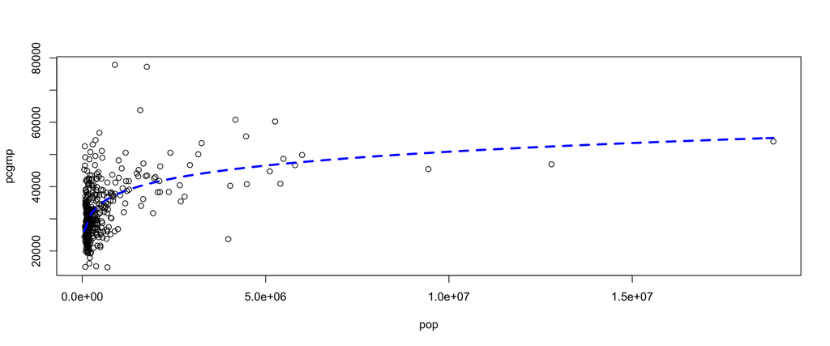